# Candidate Take Home Exam

Qi Li

## Part 2: Genomic Data Exercise

### Import your data into R

```r
tpm.df <- read.delim("https://grnhse-ghr-prod-s2.s3.amazonaws.com/generic_attachments/attachments/461/964/700/original/GTEX.nerve_samples.PMC5359387%281%29.tpms?X-Amz-Algorithm=AWS4-HMAC-SHA256&X-Amz-Credential=AKIA4XFBRPLSTAZKHOWC%2F20210802%2Fus-east-1%2Fs3%2Faws4_request&X-Amz-Date=20210802T181713Z&X-Amz-Expires=604800&X-Amz-SignedHeaders=host&X-Amz-Signature=9c74f7fbb8d0dcfc151256fdd2348b4b9a1d4a476a0768b8c2fb00334137e527", row.names=1)
gene.names.df <- tpm.df[, 'Description', drop=FALSE]
tpm.df <- tpm.df[, !(names(tpm.df) %in% c('Description'))]
cat(paste("Number of genes in table: ", dim(tpm.df)[1]))
```

```
## Number of genes in table:  1462
```

> **Q1.** Calculated the correlations among the genes in the file. If you get any warnings from R or python when doing this, give a brief explanation of why and a solution (in code) that avoids the warnings

```r
cor_tpm <- cor(t(tpm.df))
```

```
## Warning in cor(t(tpm.df)): the standard deviation is zero
```

```r
gene.tpm.sd <- apply(tpm.df,1, sd, na.rm = TRUE)
zerovariance.genes <- names(gene.tpm.sd[gene.tpm.sd == 0])
apply(tpm.df[zerovariance.genes,],1, mean, na.rm = TRUE)
```

```
##       ENSG00000242854.1       ENSG00000239304.1       ENSG00000271595.1
##                       0                       0                       0
##       ENSG00000225740.1       ENSG00000271123.1       ENSG00000232029.1
##                       0                       0                       0
##       ENSG00000234131.1       ENSG00000227915.1       ENSG00000231540.1
##                       0                       0                       0
##       ENSG00000234081.1       ENSG00000270535.1       ENSG00000232695.1
##                       0                       0                       0
##       ENSG00000227867.1 ENSG00000228410.6_PAR_Y       ENSG00000248877.2
##                       0                       0                       0
##       ENSG00000282831.1       ENSG00000244528.1       ENSG00000231523.1
##                       0                       0                       0
##       ENSG00000250857.3       ENSG00000227247.1       ENSG00000232764.1
##                       0                       0                       0
##       ENSG00000227251.1       ENSG00000224210.1       ENSG00000232976.1
##                       0                       0                       0
##       ENSG00000227837.1       ENSG00000250627.2
##                       0                       0
```

While calculating the correlation coefficient of genes, we received a warning above. After investigation, we found out that the read counts of genes have zero variance are zeros in all samples. This may be caused in the process of sample collection or library preparation. But these zero-variance genes will be removed in our next step.

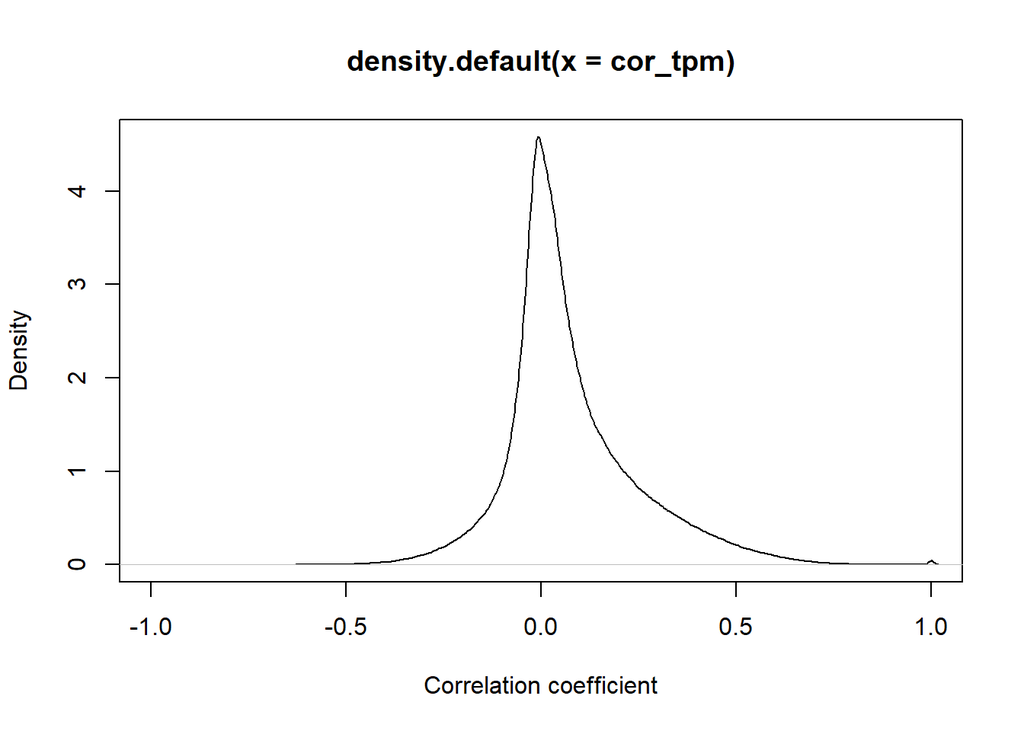

```r
tpm.df_T <- t(tpm.df)
zv <- apply(tpm.df_T, 2, function(x) length(unique(x)) == 1)
tpm.df_T <- tpm.df_T[, !zv]
cor_tpm <- cor(tpm.df_T)
plot(density(cor_tpm), xlab="Correlation coefficient", xlim = c(-1,1))
```

From the distribution curve, we can tell most gene pairs shows no relationship in expression level (w correlation coefficients close to 0).

> **Q2.** What are the top 10 pairs of most correlated genes? What are the 10 pairs of most anti-correlated genes?

```r
flattenCorrMatrix1 <- function(cormat) {
  ut <- upper.tri(cormat)
  resData <- data.frame(
    row = rownames(cormat)[row(cormat)[ut]],
    column = rownames(cormat)[col(cormat)[ut]],
    cor  =(cormat)[ut]
    )
  colnames(resData) <- c("gene_1", "gene_2", "correlation")
  return(resData)
}
# Write a function that takes the input data and can return either correlated or anti-correlated
# gene pairs, and an arbitrary number of pairs
returnGenePairs <- function(corlist, number) {
  if(number == 10){
    return(tail(cor_tpm[order(corlist$correlation),], 10))
  } else if (number == -10) {
    return(head(cor_tpm[order(corlist$correlation),], 10))
  } else {
    return(sample_n(corlist, 10))
  }}

cor_tpm <- flattenCorrMatrix1(cor_tpm)
correlatedGenes <- returnGenePairs(cor_tpm, 10)
antiCorrelatedGenes <- returnGenePairs(cor_tpm, -10)
print("10 pairs of most correlated genes list below,")
```

```
## [1] "10 pairs of most correlated genes list below,"
```

```r
correlatedGenes
```

```
##                     gene_1             gene_2 correlation
## 1026968 ENSG00000204071.10 ENSG00000105409.16   0.9651398
## 1026553 ENSG00000176884.14 ENSG00000105409.16   0.9697051
## 979127  ENSG00000138100.13 ENSG00000141161.11   0.9720582
## 137429  ENSG00000113327.15 ENSG00000176884.14   0.9735591
## 1026664 ENSG00000152954.11 ENSG00000105409.16   0.9799653
## 410601  ENSG00000152954.11  ENSG00000166111.9   0.9836850
## 201698  ENSG00000113327.15 ENSG00000152954.11   0.9850392
## 1026431 ENSG00000113327.15 ENSG00000105409.16   0.9881412
## 410368  ENSG00000113327.15  ENSG00000166111.9   0.9897800
## 1026935  ENSG00000166111.9 ENSG00000105409.16   0.9925702
```

```r
print("10 pairs of most anti-correlated genes list below")
```

```
## [1] "10 pairs of most anti-correlated genes list below"
```

```r
antiCorrelatedGenes
```

```
##                    gene_1             gene_2 correlation
## 165938 ENSG00000074800.13 ENSG00000109339.19  -0.6117118
## 875463 ENSG00000121775.17 ENSG00000184205.14  -0.6038108
## 56828   ENSG00000240771.6 ENSG00000074800.13  -0.5945591
## 56835  ENSG00000129675.15 ENSG00000074800.13  -0.5889547
## 446012 ENSG00000078269.14 ENSG00000133142.17  -0.5879209
## 131140  ENSG00000254986.7 ENSG00000198932.12  -0.5878213
## 395967 ENSG00000132879.13 ENSG00000152377.13  -0.5858784
## 396494 ENSG00000108018.15 ENSG00000152377.13  -0.5847728
## 875127 ENSG00000157191.19 ENSG00000184205.14  -0.5841812
## 263777 ENSG00000185386.14 ENSG00000082996.19  -0.5805068
```

> **Q3.** For each of the top 10 correlated gene pairs in question #2, find other genes that are highly correlated or anti-correlated with that pair. For the purpose of this question, “highly correlated” means a correlation coefficient with an absolute value above 0.7 and a p-value less than 0.05. Add a multiple hypothesis correction to the p-values.

The function cor() returns only the correlation coefficients between genes. In the next questions, the Hmisc R package will be used to calculate the correlation p-values.

```r
if(!require("tidyverse")) install.packages("tidyverse")
if (!require("Hmisc")) install.packages("Hmisc")
library(tidyverse)
library("Hmisc")

flattenCorrMatrix2 <- function(cormat, pmat) {
  ut <- upper.tri(cormat)
  resData <- data.frame(
    row = rownames(cormat)[row(cormat)[ut]],
    column = rownames(cormat)[col(cormat)[ut]],
    cor  =(cormat)[ut],
    p = pmat[ut]
    )
  colnames(resData) <- c("gene_1", "gene_2", "correlation", "p-value")
  return(resData)
}
```

```r
# calculate mean TPM values for each pair
tpm_df <- tpm.df_T %>% as.data.frame()
for( row in 1:10) {
  GENE1 <- correlatedGenes[row, "gene_1"]
  GENE2 <- correlatedGenes[row, "gene_2"]
  new_col <- tpm_df %>% mutate(tpmMEAN = rowMeans(select(., GENE1, GENE2))) %>% select(tpmMEAN)
  tpm_df[,paste(GENE1, GENE2, sep="_")] <- new_col
}
```

```
## Note: Using an external vector in selections is ambiguous.
## i Use `all_of(GENE1)` instead of `GENE1` to silence this message.
## i See <https://tidyselect.r-lib.org/reference/faq-external-vector.html>.
```

```
## Note: Using an external vector in selections is ambiguous.
## i Use `all_of(GENE2)` instead of `GENE2` to silence this message.
## i See <https://tidyselect.r-lib.org/reference/faq-external-vector.html>.
```

```r
res<-rcorr(as.matrix(tpm_df))
res2 <- flattenCorrMatrix2(res$r, res$P)
threePairs <- res2 %>% filter(abs(correlation) > 0.7 & `p-value` < 0.05) %>%
        filter((grepl("_", gene_1) | grepl("_", gene_2)) & !(grepl("_", gene_1) & grepl("_", gene_2)))
colnames(threePairs) <- c("thirdGene", "genePair", "correlation", "p-value")
threePairs <- threePairs[-apply(threePairs, 1, function(x) grepl(x['thirdGene'], x['genePair'], fixed=TRUE)),]
cat(paste(length(unique(threePairs$thirdGene)), "genes that are highly correlated or anti-correlated with the pairs,"))
```

```
## 41 genes that are highly correlated or anti-correlated with the pairs,
```

```r
unique(threePairs$thirdGene)
```

```
##  [1] "ENSG00000078725.12" "ENSG00000113327.15" "ENSG00000182256.12"
##  [4] "ENSG00000146360.8"  "ENSG00000165370.1"  "ENSG00000176884.14"
##  [7] "ENSG00000152954.11" "ENSG00000065609.14" "ENSG00000132639.12"
## [10] "ENSG00000074317.10" "ENSG00000166111.9"  "ENSG00000127561.14"
## [13] "ENSG00000204071.10" "ENSG00000173452.13" "ENSG00000179292.4"
## [16] "ENSG00000151952.15" "ENSG00000165548.10" "ENSG00000174521.7"
## [19] "ENSG00000164853.8"  "ENSG00000156687.10" "ENSG00000163032.11"
## [22] "ENSG00000105278.10" "ENSG00000197106.6"  "ENSG00000144290.16"
## [25] "ENSG00000105409.16" "ENSG00000147256.11" "ENSG00000178233.17"
## [28] "ENSG00000029534.19" "ENSG00000148677.6"  "ENSG00000165887.11"
## [31] "ENSG00000108515.17" "ENSG00000166317.11" "ENSG00000224982.3"
## [34] "ENSG00000158022.6"  "ENSG00000138100.13" "ENSG00000147573.16"
## [37] "ENSG00000177238.13" "ENSG00000141161.11" "ENSG00000152578.12"
## [40] "ENSG00000113763.10" "ENSG00000161681.15"
```

> **Q4.** BONUS Question (optional)

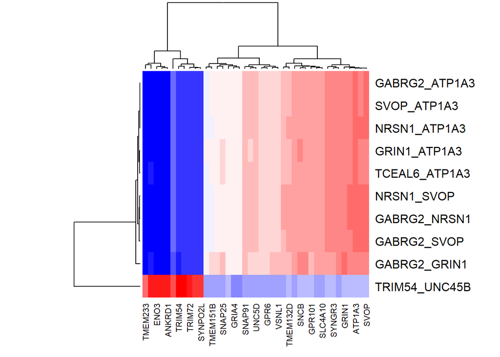

```r
res3 <- res$r[unique(threePairs$thirdGene), unique(threePairs$genePair)]
newColName = c()
for(colName in colnames(res3)){
  newColName <- c(newColName, paste(gene.names.df[strsplit(colName, "_")[[1]][1],], gene.names.df[strsplit(colName, "_")[[1]][2],], sep="_"))
}
newRowName = c()
for(rowName in row.names(res3)){
  newRowName <- c(newRowName, gene.names.df[rowName,])
}
colnames(res3) <- newColName
row.names(res3) <- newRowName

col<- colorRampPalette(c("blue", "white", "red"))(20)
heatmapRes <- heatmap(x = t(res3), col = col, symm = FALSE)
```

Cluster heat map of gene expression data. Top 10 correlated gene pairs have been labeled on the right side and other genes that are highly correlated with these pairs are labeled on the bottom. 41 genes have been clustered at least two clusters. Genes TMEM233, ANK1, ENO3, ANKRD2, ANKRD1, TRIM55, TRIM54, UNC45B, TRIM72, TRIM63 and SYNPO2L can be clustered in one group and rests are another group.